# Test CLT with Exponentials

JeremiShane

11/24/2017

## Summary

In testing the Central Limit Theorem (CLT) with means from Exponential distributions, the evidence shows the CLT to hold true.

## Overview

The central limit theorem (CLT) establishes that, in most situations, when independent random variables are added, their properly normalized sum tends toward a normal distribution (informally a “bell curve”) even if the original variables themselves are not normally distributed. We will evaluate this theory with the averages/means of simulated exponentials.

A comparison of the means or averages of 1000 simulated exponential distributions in R with the Central Limit Theorem. This investigation uses simulations with size(n) = 10, 20, 30 40, 50 and 100 exponentials.

Note - The simulation with means from forty exponentials will be used by default, when only one distribution is evaluated. Referred to as ‘forty_mean’

From Wikipedia, the exponential distribution occurs naturally when describing the lengths of the inter-arrival times in a homogeneous Poisson process. The exponential distribution describes the time for a continuous process to change state

This analysis is organized as follows:  
1. Simulations  
2. Sample Mean versus Theoretical Mean  
3. Sample Variance versus Theoretical Variance  
4. Distribution

First, let’s have a quick look at an exponential distribution and a normal distribition.

Lambda is the rate parameter for rexp() exponential simulation function in R. We will be using lambda=.2. Mean of the exponential distribution is 1/lambda, and standard deviation is also 1/lambda.

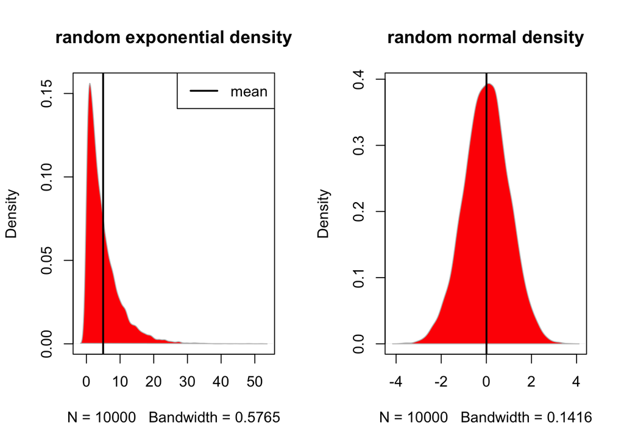

We can see from these two simple histograms that an exponential distribution does not look normal. To carry out our experiment, we will look at the means of multiple exponential distributions. The Central limit theorem tells us that even though the exponential distribution is not normal, the means from large enough number of exponential distributions should approach normal.

## Simulation of Exponentials

```r
set.seed(23)  ## set seed for reproducability
## run 1000 simulations
nsims <- 1000
n <- 40 ## our default number of exponentials
ten_mean = sapply(1:nsims, function(x) {mean(rexp(10, lambda))})
twenty_mean = sapply(1:nsims, function(x) {mean(rexp(20, lambda))})
thirty_mean = sapply(1:nsims, function(x) {mean(rexp(30, lambda))})
forty_mean = sapply(1:nsims, function(x) {mean(rexp(n, lambda))})
fifty_mean = sapply(1:nsims, function(x) {mean(rexp(50, lambda))})
hundred_mean = sapply(1:nsims, function(x) {mean(rexp(100, lambda))})
```

## Simulated Mean vs. Theoretical Mean

With lambda = .2, an exponential distribution should have mean = 1/lambda = 5, and standard deviation = 1/lambda as well. We would expect the means from 1000 of these exponential distributions to be a normal distribution around 5, from the Central Limit Theorem. Let’s have a look at the means of our 1000 means compared to the 1/lambda = 5.

```
##   theoreticalMean fortyMean
## 1               5  4.984891
```

These calculations show that the theoretical mean and the mean from each of our simulations are very close.

## Simulated Variance vs. Theoretical Variance

Variance…  
- of an exponential distribution is 1/lambda^2  
- for a normal distribution is sd^2

```
##   theoreticalVariance simulatedVariance
## 1               0.625         0.6584433
```

We see here that the theoretical variance and calculated variance from our simulated distribution is very close.

## Distribution

Let’s look at a histogram distribution and a qq plot of our forty_mean simulation.

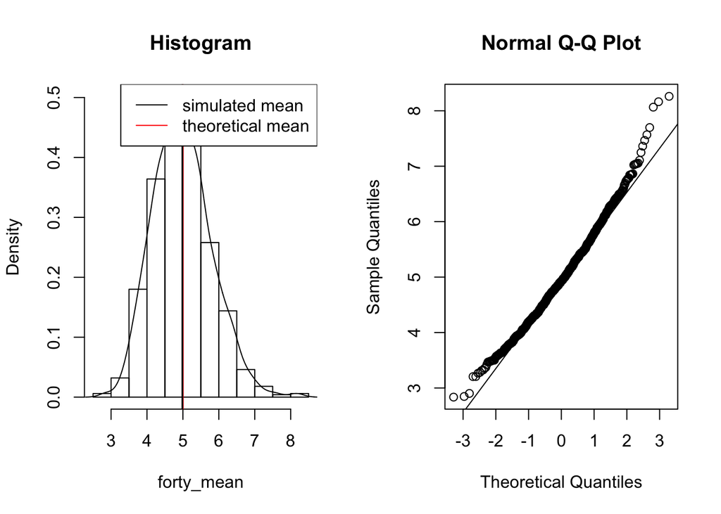

```r
par(mfrow=c(1,2), oma=c(0,0,0,0))
hist(forty_mean, breaks=10, prob=TRUE, main="Histogram")
lines(density(forty_mean), col="black")
## the theoretical center of distribution is 1/lambda (vertical line at mean)
abline(v=1/lambda, col="red", lty=1, lwd=1.5)
## our simulated mean/center
abline(v=mean(forty_mean), col="black", lwd=1.5)
legend('topright', c("simulated mean", "theoretical mean"), lty=c(1,1), col=c("black", "red"))
qqnorm(forty_mean); qqline(forty_mean)
```

Both of these indicate the Central Limit Theorem is holding true. The distribution is forming a normal bell curve around 5.

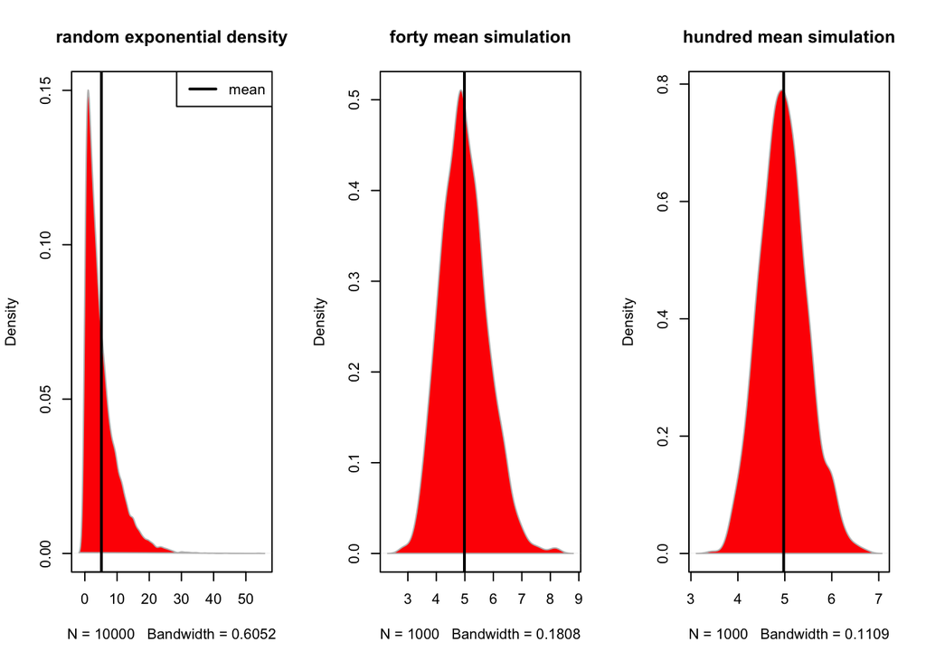

The larger n gets, the closer to normal it gets. It is safe to say that our experiment shows clearly the Central Limit Theorem holding true.